# 上海市新冠感染者日新增数据(隔日更新)

Yunlong(@algorithmx)

2022-05-06

### [回主页](https://algorithmx.github.io/)

### [下载 R markdown 源代码](https://algorithmx.github.io/shcovid19/shcovid19.Rmd)

```r
knitr::opts_chunk$set(echo = TRUE)

library(comprehenr)
library(deSolve)
population <- 2.5e7
# data
df <- read.csv("SH_COVID19.csv")
df$date <- as.Date(df$date)
df$new.total.cases <- df$new.asympt.cases+df$new.cases
df$A <- cumsum(df$new.total.cases)/population
df$t <- seq(from=0,to=nrow(df)-1,by=1)
```

## 数据来源

所有数据来自微信公众号“上海发布”每日推送。[这里](https://algorithmx.github.io/shcovid19/SH_COVID19.csv)是我自制的表格。

```r
tail(df)
```

```
##          date new.asympt.cases new.cases released new.total.cases          A  t
## 46 2022-05-01             6606       727    33710            7333 0.02388844 45
## 47 2022-05-02             5395       274    31102            5669 0.02411520 46
## 48 2022-05-03             4722       260    11442            4982 0.02431448 47
## 49 2022-05-04             4390       261    14872            4651 0.02450052 48
## 50 2022-05-05             4024       245    11796            4269 0.02467128 49
## 51 2022-05-06             3961       253    13289            4214 0.02483984 50
```

## 数据呈现

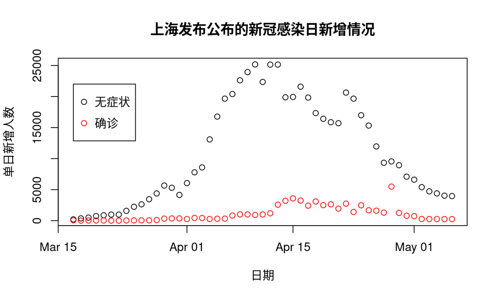

```r
plot(df$date,df$new.asympt.cases, col="black",
     xlab="日期", ylab="单日新增人数")
points(df$date,df$new.cases, col="red")
legend(df$date[1], 22000, c("无症状","确诊"), col=c("black","red"),
       pch=c(1,1), y.intersp=1.5)
title("上海发布公布的新冠感染日新增情况")
```

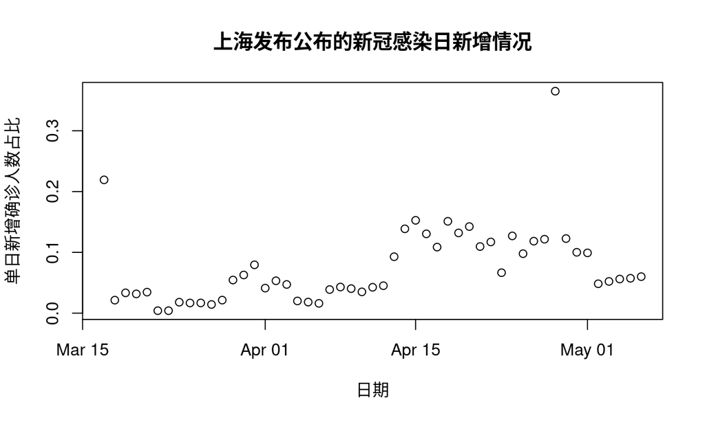

```r
plot(df$date, df$new.cases/(df$new.asympt.cases+df$new.cases), col="black",
     xlab="日期", ylab="单日新增确诊人数占比")
title("上海发布公布的新冠感染日新增情况")
```

## 累计感染人数增长Logistic模型

由于缺乏恢复患者数量信息，我们**只能**对累计感染人数(记为$T_n$)进行分析。之前我们展示的是日新增数字，是marginal data，而$T_n$根据定义是 cumulative data，形状如下：

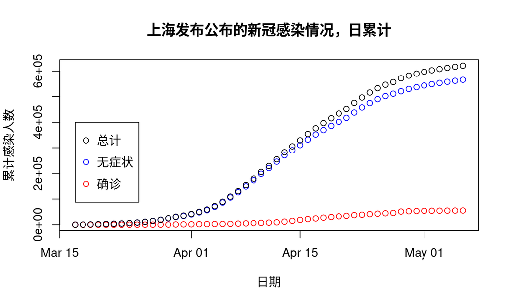

```r
T1n <- cumsum(df$new.cases)
T2n <- cumsum(df$new.asympt.cases)
Tn <- T1n + T2n
plot(df$date,T2n, col="blue",  ylim=c(0,6.2e5),
     xlab="日期", ylab="累计感染人数")
points(df$date, T1n, col="red")
points(df$date, Tn, col="black")
legend(df$date[1], 4e5, c("总计","无症状","确诊"), col=c("black","blue","red"),
       pch=c(1,1), y.intersp=1.5)
title("上海发布公布的新冠感染情况，日累计")
```

这数据真比大腿还光滑，难以置信。但不管你信不信，我是信了，因为我得做拟合。

能使累积感染者比例$I_n$呈现平台的、最简单的模型，就是人口增长的Logistic模型。为了使模型给出的感染人数不至于永远增加，我们引进了一个容量参数 $K$。模型如下：

$$\begin{equation}
\frac{{\rm d}I}{{\rm d}t} = a I\left(1-\frac{I}{K}\right)
\end{equation}$$

它的解为：

$$\begin{equation}
I(t) = \frac{K}{1+\exp[-a(t-b)]},\;I(0) = \frac{K}{1+\exp(ab)}.
\end{equation}$$

如果我们认为 $I_n = I(n\Delta t)$ 的话，就可以对这个模型进行拟合了。

```r
infection <- data.frame(In = Tn / population,
                        t = seq(from=0,to=length(df$date)-1,by=1))
fit_logistic <- nls(In ~ SSlogis(t, Asym, xmid, scal), data=infection)
summary(fit_logistic)
```

```
##
## Formula: In ~ SSlogis(t, Asym, xmid, scal)
##
## Parameters:
##       Estimate Std. Error t value Pr(>|t|)
## Asym 2.514e-02  1.803e-04  139.48   <2e-16 ***
## xmid 2.876e+01  1.461e-01  196.83   <2e-16 ***
## scal 5.774e+00  1.085e-01   53.23   <2e-16 ***
## ---
## Signif. codes:  0 '***' 0.001 '**' 0.01 '*' 0.05 '.' 0.1 ' ' 1
##
## Residual standard error: 0.0003603 on 48 degrees of freedom
##
## Number of iterations to convergence: 0
## Achieved convergence tolerance: 1.742e-06
```

虽然模型是猜的，但结果还算显著。如果把数据比作大腿的话，那么余项就是腿毛。统计分析专家可能特别喜欢看腿毛。Voilà :

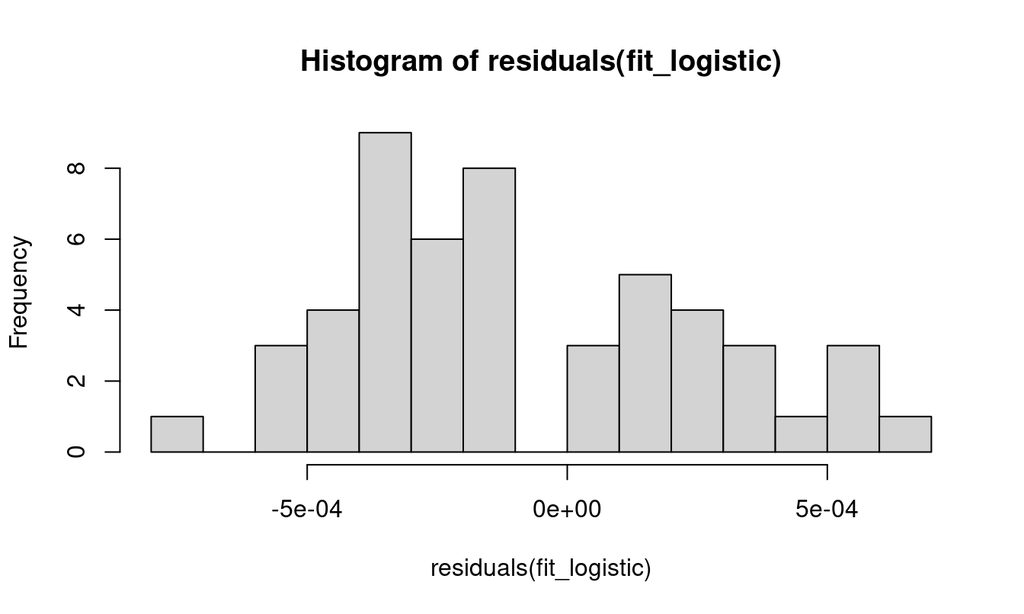

```r
hist(residuals(fit_logistic),breaks=10)
```

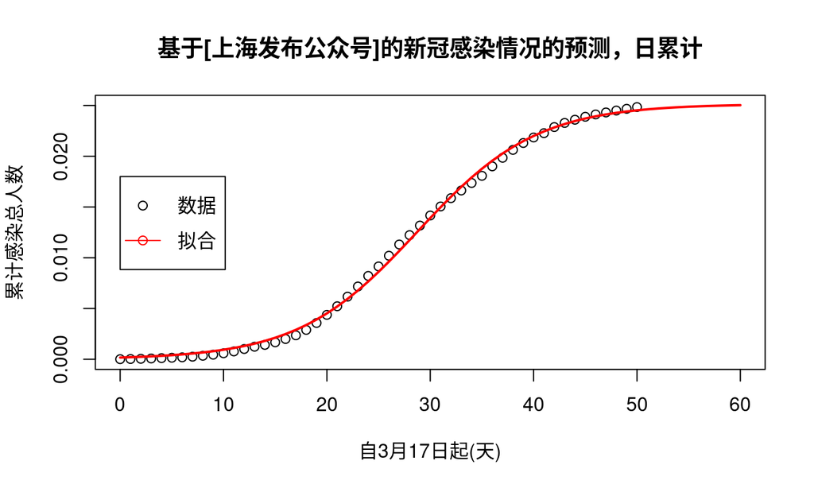

```r
t1 <- seq(from=0,to=60,by=1)
plot(In ~ t, data=infection, col="black", xlim=c(0,60), ylim=c(0,0.025),
     xlab="自3月17日起(天)", ylab="累计感染总人数")
lines(t1, as.numeric(predict(fit_logistic, newdata=data.frame(t=t1))), col="red", lwd=2)
legend(0, 0.018, c("数据","拟合"), col=c("black","red"),
       pch=c(1,1), lty=c(0,1), y.intersp=1.5)
title("基于[上海发布公众号]的新冠感染情况的预测，日累计")
```

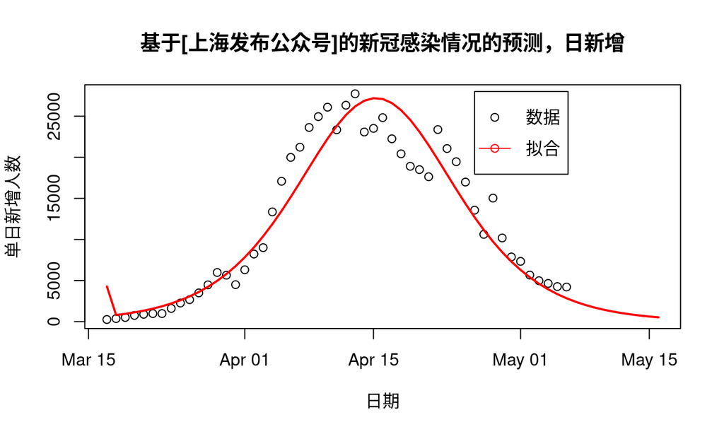

```r
t1 <- seq(from=0,to=60,by=1)
d <- diff(c(0,as.numeric(predict(fit_logistic, newdata=data.frame(t=t1)))))
newdate <- seq.Date(from=df$date[1],to=as.Date(df$date[1]+60),by="day")
plot(df$date, df$new.total.cases, col="black", xlim=c(newdate[1],newdate[61]),
     xlab="日期", ylab="单日新增人数")
lines(newdate, population * d, col="red", lwd=2)
legend(newdate[41], 28000, c("数据","拟合"), col=c("black","red"),
       pch=c(1,1), lty=c(0,1), y.intersp=1.5)
title("基于[上海发布公众号]的新冠感染情况的预测，日新增")
```

由于我们使用了人口增长Logistic模型，引进容量参数 $K$ (对应`Asym`)，它估计为 0.0251418，也就是说，到解封的时候，每千名上海居民会有大约 25.1 人曾感染过新冠。我们也可以看到，模型预测，日新增感染数的拐点已经过了～

## S-I-R 模型

### 说明

S-I-R 模型指出，有机会感染者(susceptible)比例 $S$，已感染者(infected)比例 $I$，恢复者(recovered)比例 $R$ 存在如下关系：

$$\begin{align}
\frac{{\rm d}S}{{\rm d}t} & =-\beta S I\\
\frac{{\rm d}I}{{\rm d}t} & =\beta SI-\gamma I\\
\frac{{\rm d}R}{{\rm d}t} & =\gamma I\\
1 & = S + I + R
\end{align}$$

模型参数说明：

- $\beta$ rate of infection
- $\gamma$ rate of recovery

首先需要一个模拟器，准确说是常微分方程的integrator，求出SIR常微分方程给定参数和初始条件后的数值解。I have eliminated the first equation for $dS/dt$ since $S=1-I-R$ can be derived from the other two equations.

```r
SIR_model <- function(t, state, parameters) {
  with(as.list(c(state, parameters)),{
    dI  <-  beta*I*(1-(I+R)) - gamma*I
    dR  <-  gamma*I
    list(c(dI,dR))
  }) # end with(as.list ...
}

SIR <- function(t, beta, gamma, I0, R0){
  params <- c(beta=beta,gamma=gamma)
  state  <- c(I=I0, R=R0)
  out <- ode(y = state, times = t,
             func = SIR_model,
             parms = params,
             method="rk4")
  return(out)
}
```

来看几个例子。假设在一个完全健康的群体中初始感染者只有极少的比例：

$$I(0)=10^{-7},\;R(0)=0,\;S(0)=1-I(0)-R(0).$$

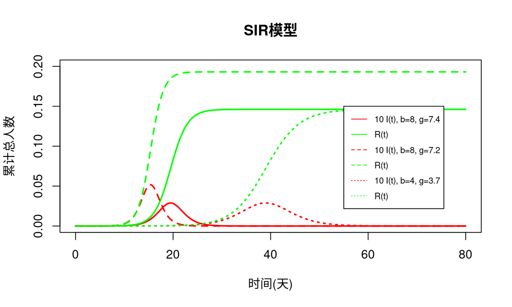

```r
t <- seq(from=0, to=80, by=0.02)
simul1 <- as.data.frame(SIR(t, 8, 7.4,1e-7,0))
simul2 <- as.data.frame(SIR(t, 8, 7.2,1e-7,0))
simul3 <- as.data.frame(SIR(t, 4, 3.7,1e-7,0))
plot( simul1$time, 10*simul1$I, lty=1, col="red", type="l", lwd=2,
      xlim=c(0,80),ylim=c(0,0.2),
      xlab="时间(天)", ylab="累计总人数" )
lines(simul1$time, simul1$R, lty=1, col="green",lwd=2)
lines(simul2$time, 10*simul2$I, lty=2, col="red",  lwd=2)
lines(simul2$time, simul2$R, lty=2, col="green",lwd=2)
lines(simul3$time, 10*simul3$I, lty=3, col="red",  lwd=2)
lines(simul3$time, simul3$R, lty=3, col="green",lwd=2)
legend(55, 0.15, c("10 I(t), b=8, g=7.4","R(t)",
                  "10 I(t), b=8, g=7.2","R(t)",
                  "10 I(t), b=4, g=3.7","R(t)"),
       col=c("red","green","red","green","red","green"),
       lty=c(1,1,2,2,3,3), y.intersp=1.5, cex = 0.7)
title("SIR模型")
```

从上图可以看出，$\beta$小，累计感染比率峰值出现得较晚；$\gamma$大，累计感染比率峰值较低。

### 拟合准备：估算 $\beta$, $\gamma$ 参数

$$S(t) = S(0) \exp\left( -\tilde{\beta}
\left<I\right> t \right).$$
而得到 $c=-\tilde{\beta} \left<I\right>$ 的值、进而得到 $\beta$ 的一个估计 $\tilde{\beta}$ 很容易。下面是代码：

```r
i0 <- 1
An <- (1 / population) * cumsum(df$new.cases + df$new.asympt.cases)
Sn <- (1-An)[i0:(i0+10)]
log_Sn <- log(Sn)
t  <- seq(from=i0-1,to=i0+10-1,by=1)
fit_for_beta <- lm(log_Sn ~ t)
summary(fit_for_beta)
```

```
##
## Call:
## lm(formula = log_Sn ~ t)
##
## Residuals:
##        Min         1Q     Median         3Q        Max
## -1.168e-04 -3.386e-05  2.082e-05  4.659e-05  6.887e-05
##
## Coefficients:
##               Estimate Std. Error t value Pr(>|t|)
## (Intercept)  6.560e-05  3.532e-05   1.857   0.0963 .
## t           -5.415e-05  5.971e-06  -9.070 8.02e-06 ***
## ---
## Signif. codes:  0 '***' 0.001 '**' 0.01 '*' 0.05 '.' 0.1 ' ' 1
##
## Residual standard error: 6.263e-05 on 9 degrees of freedom
## Multiple R-squared:  0.9014, Adjusted R-squared:  0.8904
## F-statistic: 82.26 on 1 and 9 DF,  p-value: 8.016e-06
```

```r
c <- as.numeric(coef(fit_for_beta)["t"])
beta_estim <- -c/(An[i0]) # tends to overestimate
beta_estim
```

```
## [1] 5.20725
```

修改 `i0` 的值来调节估算采用的起始日期，我发现结果变化很大。于是想出第二种办法，定义 $A=I+R$，然后写出 $A(t)$ 满足的微分方程

$$\frac{{\rm d}A}{{\rm d}t} =
\beta\left(1-A\right)I$$

并认为 $R\approx0$ 进而 $A\approx I$(从结果看出这个近似很不好)，于是解得

$$A(t) = \frac{1}{1+\exp(-\beta t
+C_0)},\;A(0)=\frac{1}{1+\exp(C_0)},$$

这样我们可以通过拟合 $\ln(1/A-1)\sim t$ 来定出 $\beta$。代码如下：

```r
i0 <- 1
An <- (1 / population) * cumsum(df$new.cases + df$new.asympt.cases)
Yn <- log(1/An-1)[i0:(i0+10)]
t  <- seq(from=i0-1,to=i0+10-1,by=1)
fit_for_beta1 <- lm(Yn~t)
summary(fit_for_beta1)
```

```
##
## Call:
## lm(formula = Yn ~ t)
##
## Residuals:
##      Min       1Q   Median       3Q      Max
## -0.30622 -0.19438 -0.01764  0.10758  0.58714
##
## Coefficients:
##             Estimate Std. Error t value Pr(>|t|)
## (Intercept) 10.88656    0.15765   69.06 1.42e-13 ***
## t           -0.37059    0.02665  -13.91 2.17e-07 ***
## ---
## Signif. codes:  0 '***' 0.001 '**' 0.01 '*' 0.05 '.' 0.1 ' ' 1
##
## Residual standard error: 0.2795 on 9 degrees of freedom
## Multiple R-squared:  0.9555, Adjusted R-squared:  0.9506
## F-statistic: 193.4 on 1 and 9 DF,  p-value: 2.172e-07
```

```r
beta_estim1 <- -as.numeric(coef(fit_for_beta1)["t"])
beta_estim1
```

```
## [1] 0.3705919
```

由于 $R(t)$ 数据缺失，$\gamma$ 无法用 SIR 公式最后一行来估算。我们也无从得知 $I(t)$ 而只知道 $A(t)=I(t)+R(t)$. 但我们可以变形中间一行：

$$\frac{{\rm d}\,{\rm ln} I}{{\rm d}t}
=\beta S-\gamma,$$

做出近似 $S(t)\approx 1$ and $R(t)\approx 0$，我们可以通过 ${\rm d}\,{\rm ln} I\sim t$ 的斜率大概算一下：

```r
i0 <- 1
An <- (1 / population) * cumsum(df$new.cases + df$new.asympt.cases)
log_In <- log(An[i0:(i0+10)])
t  <- seq(from=0,to=nrow(df)-1,by=1)
t5 <- t[i0:(i0+10)]
fit_for_gamma <- lm(log_In ~ t5)
summary(fit_for_gamma)
```

```
##
## Call:
## lm(formula = log_In ~ t5)
##
## Residuals:
##     Min      1Q  Median      3Q     Max
## -0.5872 -0.1076  0.0177  0.1944  0.3063
##
## Coefficients:
##              Estimate Std. Error t value Pr(>|t|)
## (Intercept) -10.88649    0.15768  -69.04 1.42e-13 ***
## t5            0.37054    0.02665   13.90 2.18e-07 ***
## ---
## Signif. codes:  0 '***' 0.001 '**' 0.01 '*' 0.05 '.' 0.1 ' ' 1
##
## Residual standard error: 0.2795 on 9 degrees of freedom
## Multiple R-squared:  0.9555, Adjusted R-squared:  0.9506
## F-statistic: 193.3 on 1 and 9 DF,  p-value: 2.178e-07
```

```r
gamma_estim <- beta_estim - as.numeric(fit_for_gamma$coefficients["t5"])
gamma_estim
```

```
## [1] 4.836712
```

估算的结果 $\tilde{\gamma} > 0$，比较合理。

于是我们可以用刚写好的simulator结合这几个估算数字，画个图：

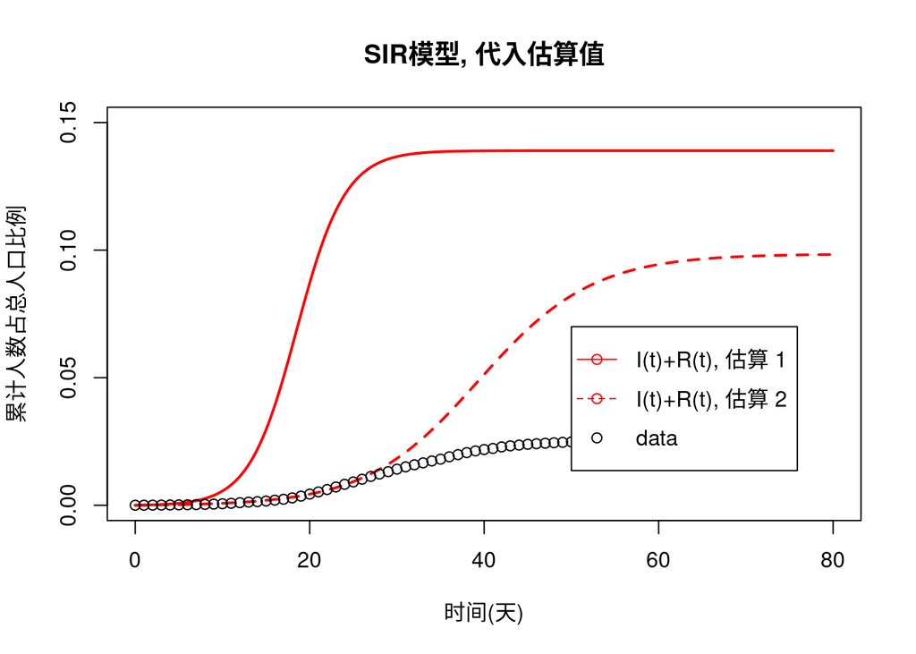

```r
i0 <- 1
An <- (1 / population) * cumsum(df$new.cases + df$new.asympt.cases)
t <- seq(from=0, to=80, by=0.02)
simul_estim  <- as.data.frame(SIR(t, beta_estim, gamma_estim, An[i0], 0))
simul_estim1 <- as.data.frame(SIR(t, 0.6*beta_estim, 0.57*beta_estim, An[i0], 0))
plot( simul_estim$time+i0-1, simul_estim$I+simul_estim$R, lty=1, col="red", type="l", lwd=2,
      xlim=c(0,80),ylim=c(0,0.15),
      xlab="时间(天)", ylab="累计人数占总人口比例" )
lines(simul_estim1$time+i0-1, simul_estim1$I+simul_estim1$R, lty=2, col="red", type="l", lwd=2)
points(A~t, data=df, col="black")
legend(50, 0.07,
       c("I(t)+R(t), 估算 1","I(t)+R(t), 估算 2","data"),
       col=c("red","red","black"),
       lty=c(1,2,0), pch=c(1,1,1), y.intersp=1.5)
title("SIR模型, 代入估算值")
```

从上图可以看出，仅用估算值代入SIR模型给出预测，在第10天后偏差很多。估算2的结果是手动调节得到的，可以看出，估算1(也就是之前根据起头数据的估算)高估了 $\beta$。所以还是需要拟合。

经过一番痛苦的尝试，我意识到，SIR 模型的参数 $\beta$, $\gamma$ 并不是好的选择。原因可以从下面的变形看出：

$$\begin{align}
\frac{{\rm d}S}{{\rm d}t} & =-\beta S I\\
\frac{{\rm d}I}{{\rm d}t} & =\beta (SI-\rho I)\\
\frac{{\rm d}R}{{\rm d}t} & =\beta \rho I\\
1 & = S + I + R
\end{align}$$

对时间轴进行伸缩，令 $\tilde{t}=\beta t$，$\gamma = \beta\rho$，得到

$$\begin{align}
\frac{{\rm d}S}{{\rm d}\tilde{t}} & = - S I\\
\frac{{\rm d}I}{{\rm d}\tilde{t}} & = (S - \rho) I\\
\frac{{\rm d}R}{{\rm d}\tilde{t}} & =\rho I\\
1 & = S + I + R
\end{align}$$

现在我们看出，$\beta$ 参数的意义是整个流行病的进程速度。**在 $\rho$ 相同的情况下，$\beta$ 越大，整个流行病的进程越快。** 参数 $\rho=\gamma/\beta$ 决定着峰值感染比率。准确说，由于

$$\frac{{\rm d}^{2}A}{{\rm
d}\tilde{t}^{2}}=\frac{{\rm d}S}{{\rm d}\tilde{t}}I+S\frac{{\rm
d}I}{{\rm d}\tilde{t}}=IS[(S-\rho)-I],$$

$\frac{{\rm d}A}{{\rm d}\tilde{t}}$ 表示日新增感染数，当它的变化率为零时，疫情拐点到来；此后，总感染数 $A$ 将趋于平稳，日新增感染数将下降。$\rho$ 的意义是在疫情拐点时 $S-I$ 的数值。而根据

$$\frac{{\rm d}\,{\rm ln} I}{{\rm
d}\tilde{t}} = S-\rho,$$

我们也可以知道当疫情接近结束时，$\rho=S(\infty)$。这段分析，也解释了之前我乱猜的人口增长 Logistic 模型拟合结果为什么很准。原因是，人口增长 Logistic 模型的渐近行为和SIR模型一致，特别是，前者的容量参数 $K$ 和后者的 $\rho$ 意义相同。甚至我们可以猜测，这两个数字的关系是 $1-\rho=K$。而我们对于 SIR 模型 $\beta$ 第二种估算，做出 $A\approx I$ 的近似，得出了一个关于 $A$ 的人口增长 Logistic 模型，且$K=1$，这实际上等于悲观地认为全部 population 将被感染。当然，这样估算的 $\beta$ 值就非常小，意味着疫情进程将会很长。

### 拟合过程

I use the $\beta$-$\rho$ parametrisation of the SIR model to perform cost function minimization. The integrator for the new parametrisation of the SIR model is:

```r
SIR_model_1 <- function(t, state, parameters) {
  with(as.list(c(state, parameters)),{
    dI  <-  beta*I*((1-(I+R)) - rho)
    dR  <-  beta*I*(rho)
    list(c(dI,dR))
  }) # end with(as.list ...
}
SIR_1 <- function(t, beta, rho, I0, R0){
  params <- c(beta=beta,rho=rho)
  state  <- c(I=I0, R=R0)
  out <- ode(y = state, times = t,
             func = SIR_model_1,
             parms = params,
             method="rk4")
  return(out)
}
```

I use `nls()` with `algorithm = "port"` to fit:

```r
A0 <- df$A[1]
f <- function(t, beta, rho, R0){
  IR <- SIR_1(t, beta, rho, A0-R0, R0)
  return(IR[,2L]+IR[,3L])
}
fit_SIR_result <- nls(
          A ~ f(t, beta, rho, R0),
          data=df,
          start = list(beta=10.0, rho=0.95, R0=0.5*A0),
          lower = c(0.1,  0.01, 0.0),
          upper = c(40.0, 1.0,   A0),
          algorithm = "port",
          trace=FALSE)
summary(fit_SIR_result)
```

```
##
## Formula: A ~ f(t, beta, rho, R0)
##
## Parameters:
##       Estimate Std. Error  t value Pr(>|t|)
## beta 1.316e+01  3.203e-01    41.10   <2e-16 ***
## rho  9.874e-01  8.048e-05 12269.18   <2e-16 ***
## R0   7.856e-06  2.221e-07    35.38   <2e-16 ***
## ---
## Signif. codes:  0 '***' 0.001 '**' 0.01 '*' 0.05 '.' 0.1 ' ' 1
##
## Residual standard error: 0.0003159 on 48 degrees of freedom
##
## Algorithm "port", convergence message: both X-convergence and relative convergence (5)
```

### 拟合结果

上面SIR模型的拟合结果可以总结到这张图中：

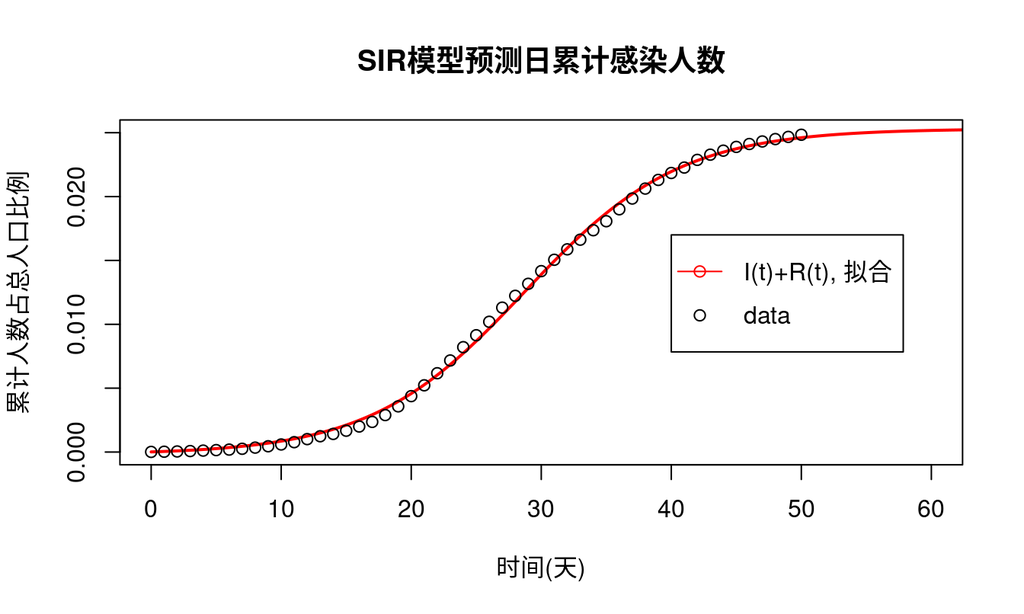

```r
# result
i0 <- 1
An <- (1 / population) * cumsum(df$new.cases + df$new.asympt.cases)
beta_pred <- as.numeric(coef(fit_SIR_result)["beta"])
rho_pred  <- as.numeric(coef(fit_SIR_result)["rho"])
R0_pred   <- as.numeric(coef(fit_SIR_result)["R0"])
SIR_pred  <- as.data.frame(
                SIR_1(seq(from=0,to=80,by=0.02),
                      beta_pred,
                      rho_pred,
                      An[i0]-R0_pred,
                      R0_pred))
# plot
plot(  SIR_pred$time+i0-1, (SIR_pred$I+SIR_pred$R),
       lty=1, col="red", type="l", lwd=2,
       xlim=c(0,60),ylim=c(0,0.025),
       xlab="时间(天)", ylab="累计人数占总人口比例" )
points(df$t, df$A, col="black")
legend(40, 0.017,
       c("I(t)+R(t), 拟合","data"),
       col=c("red","black"),
       lty=c(1,0), pch=c(1,1), y.intersp=1.5)
title("SIR模型预测日累计感染人数")
```

也可以展示模型预测的日新增感染人数：

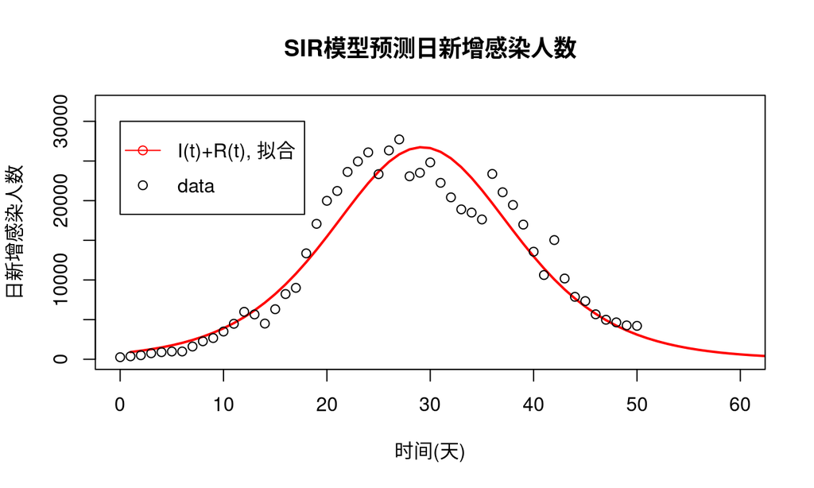

```r
# plot
i0    <- 1
msk   <- seq(from=1,to=70*50,by=50)
dates <- SIR_pred$time[msk]+i0-1
dates <- dates[2:length(dates)]
plot(  dates, population*diff((SIR_pred$I+SIR_pred$R)[msk]),
       col="red", type="l", lwd=2, xlim=c(0,60), ylim=c(0,32000),
       xlab="时间(天)", ylab="日新增感染人数" )
points(df$t, df$new.total.cases, col="black")
legend(0, 30000,
       c("I(t)+R(t), 拟合","data"),
       col=c("red","black"),
       lty=c(1,0), pch=c(1,1), y.intersp=1.5)
title("SIR模型预测日新增感染人数")
```

SIR 模型的预测与人口增长 Logistic 模型的相近：清零预计大约在3月17日后的两个月。另外，近三天的数据有点不妙，有可能是统计方法上有变化。

最近[上海发布公众号]开始公布每日从方舱释放的人数。可以认为 SIR 模型中 的日新增恢复者比例 $R(n\Delta t+\Delta t) - R(n\Delta t)$ 代表了第 $n$ 日的释放人数，从而有下面的预测：

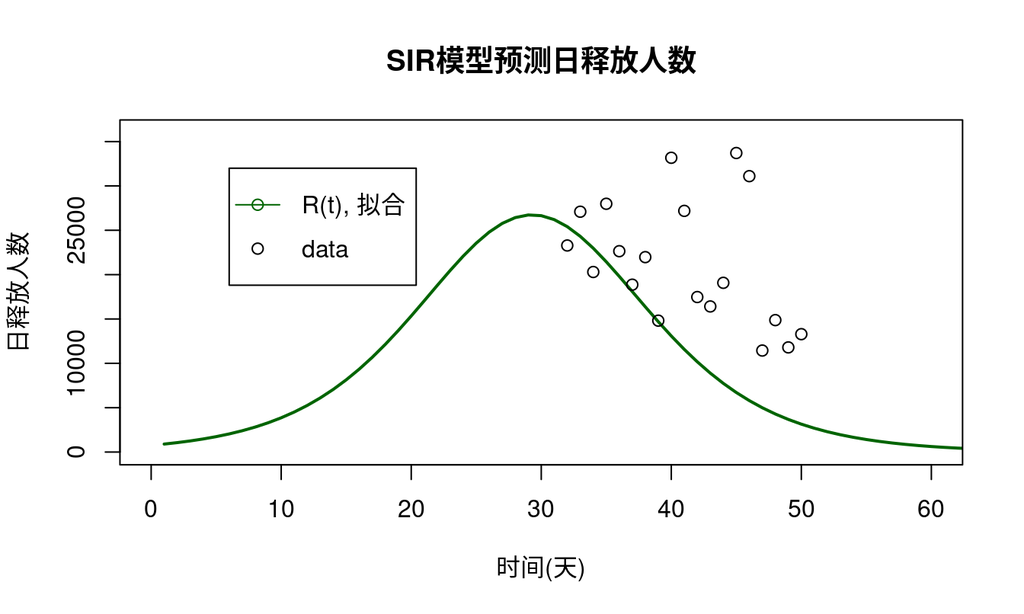

```r
# plot
i0    <- 1
msk   <- seq(from=1,to=70*50,by=50)
dates <- SIR_pred$time[msk]+i0-1
dates <- dates[2:length(dates)]
plot(  dates, population*diff(SIR_pred$R[msk]),
       col="darkgreen", type="l", lwd=2, xlim=c(0,60), ylim=c(0,36000),
       xlab="时间(天)", ylab="日释放人数" )
points(df$t, df$released, col="black")
legend(6, 32000,
       c("R(t), 拟合","data"),
       col=c("darkgreen","black"),
       lty=c(1,0), pch=c(1,1), y.intersp=1.5)
title("SIR模型预测日释放人数")
```

释放人数高于 SIR 模型预测，有多方面原因，我觉得最可能的是有前几日数据的积累。

### Daily evolution of $\beta$ and $R_0$

The basic reproduction rate $R_0$ for an SIR model is defined as the inverse of $\rho$:

$$R_0 \equiv \frac{\beta}{\gamma} =
\frac{1}{\rho}$$

I am interested in the evolution of model estimation $\beta$ and $R_0=1/\rho$ as the daily infection data is supplied. So I repeat the above non-linear regression on truncated data, up to a date `days` earlier than the last date 2022-05-06 of the data.

```r
A0 <- df$A[1]
f <- function(t, beta, rho, R0){
  IR <- SIR_1(t, beta, rho, A0-R0, R0)
  return(IR[,2L]+IR[,3L])
}
LL <- 27L
fit_SIR_result_n <- vector(mode="list",length=LL)
for (days in (LL-1L):0L){
  df_n <- df[1:(nrow(df)-days),]
  fit_SIR_result_n[[LL-days]] <- nls(
      A ~ f(t, beta, rho, R0),
      data=df_n,
      start = list(beta=10.0, rho=0.8, R0=(0.002+(LL-days)*0.006)*A0),
      lower = c(0.1,  0.01, 0.0),
      upper = c(30.0, 1.0,   A0),
      algorithm = "port",
      control=c(maxiter=20000L, tol=1e-7, minFactor=1/4000),
      trace=FALSE)
}
```

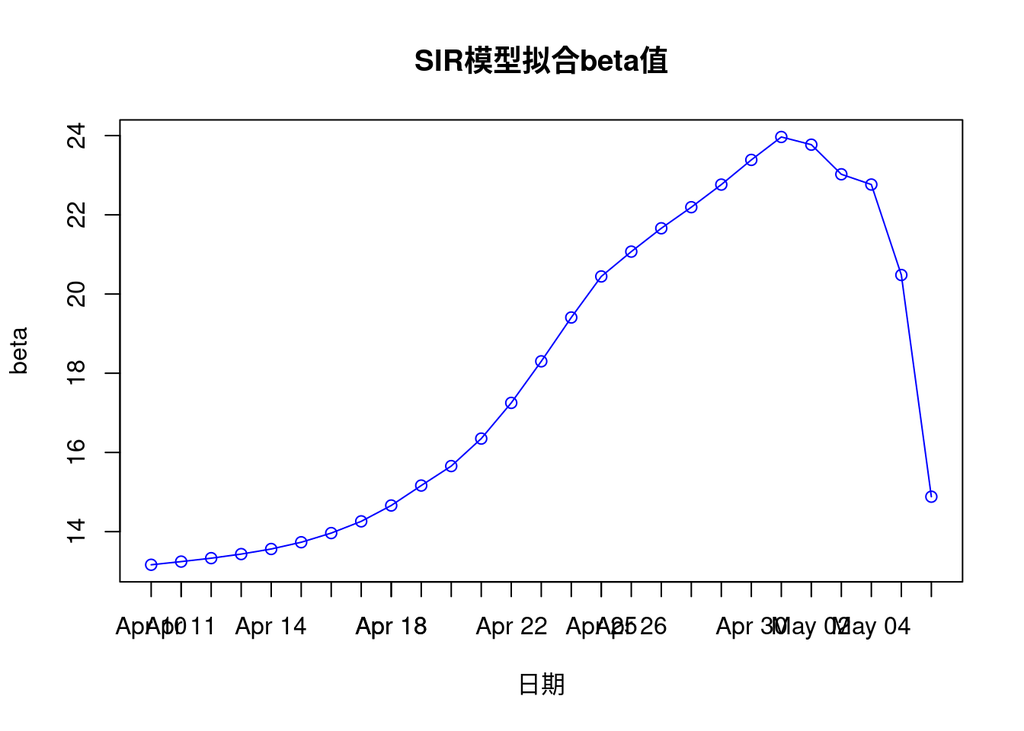

```r
beta_fit <- as.numeric(to_list(
                for (d in LL:1L)
                    coef(fit_SIR_result_n[[d]])["beta"]))
plot(df$date[(nrow(df)-(LL-1L)):nrow(df)], beta_fit,
     col="blue", xlab="日期", ylab="beta")
lines(df$date[(nrow(df)-(LL-1L)):nrow(df)], beta_fit, col="blue")
axis.Date(1, at=seq(df$date[(nrow(df)-(LL-1L))], df$date[nrow(df)],by=1))
title("SIR模型拟合beta值")
```

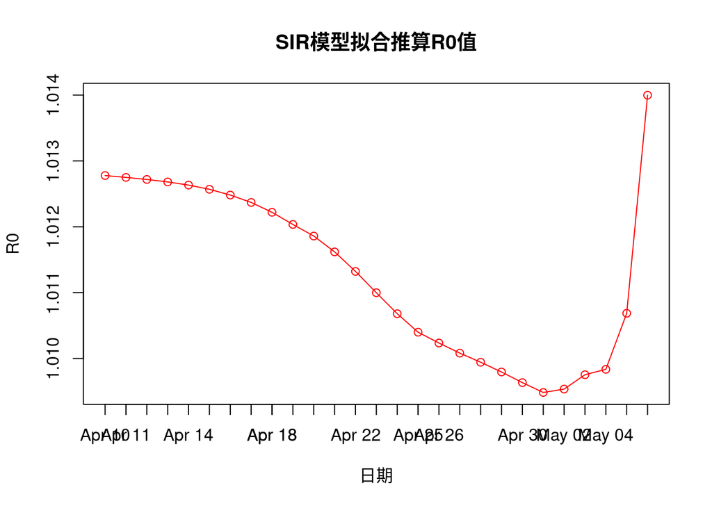

```r
rho_fit <- as.numeric(to_list(
                for (d in LL:1L)
                    coef(fit_SIR_result_n[[d]])["rho"]))
plot(df$date[(nrow(df)-(LL-1L)):nrow(df)], 1/rho_fit,
     col="red", xlab="日期", ylab="R0")
lines(df$date[(nrow(df)-(LL-1L)):nrow(df)], 1/rho_fit, col="red")
axis.Date(1, at=seq(df$date[(nrow(df)-(LL-1L))],df$date[nrow(df)],by=1))
title("SIR模型拟合推算R0值")
```

## 北京疫情数据来源

所有数据来自微信公众号“北京发布”每日推送。[这里](https://algorithmx.github.io/shcovid19/PK_COVID19.csv)是我自制的表格。

```r
population <- 2.2e7
# data
df <- read.csv("PK_COVID19.csv")
df$date <- as.Date(df$date)
df$new.total.cases <- df$new.asympt.cases+df$new.cases
df$A <- cumsum(df$new.total.cases)/population
df$t <- seq(from=0,to=nrow(df)-1,by=1)

tail(df)
```

```
##          date new.asympt.cases new.cases recovered new.total.cases            A
## 8  2022-04-30                6        53        11              59 1.454545e-05
## 9  2022-05-01                5        36        10              41 1.640909e-05
## 10 2022-05-02               11        51         5              62 1.922727e-05
## 11 2022-05-03                5        46         8              51 2.154545e-05
## 12 2022-05-04                8        42        20              50 2.381818e-05
## 13 2022-05-05               17        55         6              72 2.709091e-05
##     t
## 8   7
## 9   8
## 10  9
## 11 10
## 12 11
## 13 12
```

## 北京数据呈现

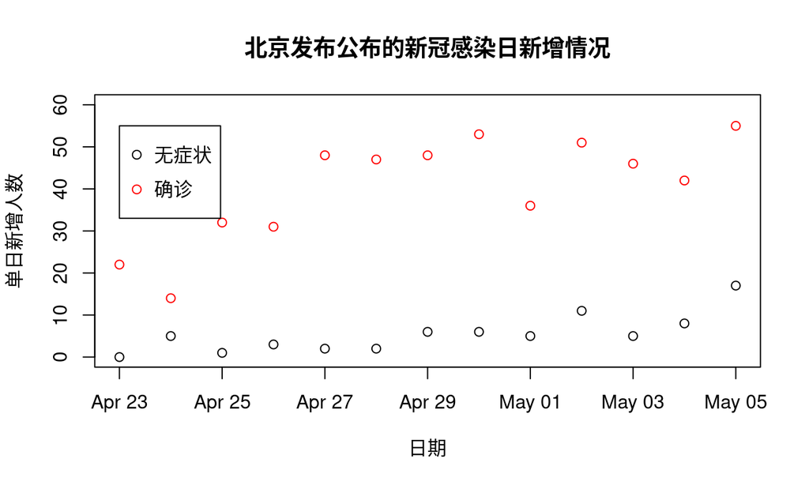

```r
plot(df$date,df$new.asympt.cases, col="black",
     xlab="日期", ylab="单日新增人数", ylim=c(0,60))
points(df$date,df$new.cases, col="red")
legend(df$date[1], 55, c("无症状","确诊"), col=c("black","red"),
       pch=c(1,1), y.intersp=1.5)
title("北京发布公布的新冠感染日新增情况")
```

**以上数据未见显著趋势，故不予拟合。若有不便之处，请您谅解。**

## TODO

Refined daily infection data; SEIR with two compartments: in camp and in hospital, assuming zero mortality.

## 新冠预测相关资料

**目前我可以拿到的数据非常少，只有不超过一百个正整数。所以，以上的预测，并没有参考价值。真正具有参考价值的，一定、必须、只能是上海卫建委的权威发布。**

如果数据充足，那么下面的链接里提供了很多模型可以用来预测新冠感染人数。

[美国疾控中心·COVID19预测模型描述](https://github.com/cdcepi/COVID-19-Forecasts/blob/master/COVID-19_Forecast_Model_Descriptions.md)